# Python Basis

[figure not shown]

# Overzicht dag 1

## Dag 1

- Python console
- Variabelen
- IDEs & Debugging
- Functies oproepen
- Scripts schrijven en uitvoeren
- Loops & if-else
- Lists
- Methoden

# Python opdrachtprompt

- Open je systeem opdrachtprompt en run command: `python`
- The python opdrachtprompt wordt ook *python REPL__ (Read-Eval-Print Loop), _python interactive shell* of *python console* genoemd

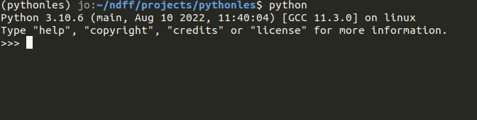

# Variabelen

- Voorbeeld: oppervlakte berekenen: `Area = width * height`
- `=`: toewijzings operator, niet (is)gelijkteken!

```python
13.41 * 4.75
```

```
63.6975
```

```python
width = 13.41
height = 4.75
width * height
```

```
63.6975
```

Een waarde aanpassen:

```python
13.41 * 2
```

```
26.82
```

```python
height = 2
width * height
```

```
26.82
```

Resultaat hergebruiken:

```python
13.41 * 2
```

```
26.82
```

```python
area = width * height
area
```

```
26.82
```

## Variabelen (2)

- “opberglocaties” voor gegevens in een programma.
- Specifiek en hoofdlettergevoelig naam
- Conventie voor namen: `kleine_letters_laag_streepje`
- **Geen automatische updates!**
- Interpretatie van links naar rechts!

```python
height = 1.433
print(area)
```

```
26.82
```

```python
area = width * height
print(area)
```

```
19.216530000000002
```

```python
volume
```

# Variabelen: Oefeningen

IntroducingVariables

De links naar de oefeningen staan op:

**github.com/latlon-dev**

*Cursus_Python_Basis*

# Scripts schrijven en uitvoeren

- Om dezelfde code meerdere keren uit te voeren, sla je hem als script.
- Je slaat je script dan op als `.py`-bestand. Deze bestanden worden ook Pyhton **modules** genoemd.
- In de systeem opdrachtprompt kan je scripts uitvoeren met `python mijn_script_naam.py`

# Commentaar

- Annotaties in het script
- Beschrijft het **waarom**
- `python` ignoreert commentaar!

```python
print('a') # hier volgt commentaar
# code tijdelijk ""uitcommentariëren"":
# print('b')
print('c') # commentaar helpt jij en anderen je script te begrijpen
```

# Python Software-ontwikkelomgevingen (IDEs)

Voordelen van een IDE:

- Project organiseren
- Debugging:
  - stap voor stap door je code
  - overzicht over alle variabelen
- Gemak en efficiëntie: autocompletion, formatting, linting

# Veel gebruikte IDEs voor Python:

- **`Python` specific**
  - PyCharm
  - WingIDE
  - [Thonny](https://thonny.org/) (voor beginners, gebruikt in deze cursus)
  - Online: [futurecoder.io](https://futurecoder.io/course/#ide)
- **Universele IDEs**:
  - [VSCode](https://code.visualstudio.com/docs/python/python-tutorial)
  - Online: [replit.com](https://replit.com/join/mgjvvgnpnw-latlondev)
- **Jupyter Notebooks**
  - Vermengen van text en code, zoals deze presentatie.
  - Online: [kaggle.com](https://www.kaggle.com/code), [Google colab](https://colab.research.google.com/), mybinder.org (voor notebooks op github)

# Debuging in een IDE

- **Breakpoints** en stap voor stap uitvoeren
- **Variabelen lijst**: waarde van alle varaiblen tijdens het uitvoeren
- **Debug console**: je kan tijdens het debuggen interactief commandos gebruiken!

## Oefen in Thonny

- Schrijf een script en zet een breakpoint
- Let goed op de variabelen lijst!
- Schrijf een script met een foutje!

```python
# hello.py
name  = "Abby"
greeting = "hello " + name + "!"
print(greeting)
print(other_greeting)
```

# For loops

```python
name = 'Bob'
for letter in name:
    print(letter)
```

letters in een woord.

## For loops (2): inspringing

- Python leidt af waar het blok begint en eindigt door inspectie van de **inspringing**,
  - Je moet een zelfde aantal spaties plaatsen voor iedere regel in het blok.
  - (Andere talen gebruiken hiervoor vaak accoladen { }.)

```python
name = 'Bob'
for i in name:
    print(i)
    print('!')
x = 0
```

```python
name = 'Bob'
for i in name:
    print(i)
print('!')
```

## For loops

[Oefenigen](https://futurecoder.io/course/#IntroducingForLoops)

# Als - dan Beslissingen

- Soms wil je keuzes maken in je programma. Als dit, dan dat.
- `if`: een voorwaarde nagaan (is leeftijd groter dan 65?) en bepaalde opdrachten uitvoeren
- net als bij `for` worden inspringen gebruikt
- `=` toewijsings operator, `==`, `<`, `!=`, ... vergelijkings operatoren!

```python
geboorteJaar = 1912
huidigJaar = 2022
leeftijd = huidigJaar - geboorteJaar
if leeftijd == 36:
    print("je bent even oud als ik!")
```

# Else en elif

```python
leeftijd = 27
if leeftijd > 65:
    print('Geniet van uw pensioen!')
    print('Jij bent', leeftijd, 'jaar')
else:
    jaren_tot_pensioen = 65 - leeftijd
    print("Nog ", jaren_tot_pensioen, " jaren werken!")
```

```
Nog  38  jaren werken!
```

```python
# check who is older:
my_age = 35
your_age = 40
if my_age == your_age: print("We're share the same age.")
elif my_age < your_age: print("I'm younger.")
else: print("I'm older.")
```

```
I'm younger.
```

[Oefeningen](https://futurecoder.io/course/#IntroducingIfStatements)

# Waarheidswaarde: Boolean Variabelen

Waarheidswaarde (ja, klopt of nee, fout) wordt in variable opgeslagen als `True` of `False`

```python
my_age = 35
your_age = 40
my_age < your_age
```

```
True
```

```python
younger = my_age < your_age
older = my_age > your_age
print(older)
```

```
False
```

## Waarheidswaarde en Beslissingen

```python
younger = True
if younger:
    print("I'm younger!")
```

```python
if False:
    print("This line never gets printed!")
```

# Functies oproepen

```python
len('Text')
```

```python
round(2.16, 1)
```

```python
round
```

- Functies zijn **herbruikbare** stukjes code
- Aantal **argumenten** die tussen haakjes staan: `round(2.15, 1)`
- Vergelijkbaar met Excel functies `=AFRONDEN(A2;1)`

## Functies oproepen (2): hulp en argumenten

```python
help(round)
```

```python
rounded_number = round(2.16)
print(rounded_number)
```

```
2
```

```python
round(222.16, -2)
```

```
200.0
```

## Functies oproepen: extra oefeningen

[Extra oefeningen (NL)](https://cscircles.cemc.uwaterloo.ca/2-functions-nl/)

# Lijsten

- Data Science, GIS: vaak reeks van waarden
- Python: `list` (In vele andere programmeertalen : `array`)

```python
measurement0 = 0.01
measurement1 = 11.1
measurement2 = 12.2
measurement3 = 13.3
measurement4 = 14.4
```

```python
measurements = [0.01, 11.1, 12.2, 13.3, 14.4]
print(measurements)
```

```python
# loop over the the list and print one element per line:
for i in measurements:
    print(i)
```

## Lijsten (2): index

- Lijst element oproepen met idex `measurements[0]`
- **het eerste element heeft index 0!**

```python
measurements[0]
```

```python
measurements[2] = 2222.2
measurements
```

## Lijsten (3): Slicing & lengte

- bereik van een lijst "selecteren": `measurements[1:2]` verglijkbaar met Excel bereik (A1:A4)

```python
print(measurements[0:3])
```

```python
print(measurements[-2:])
```

```python
print(len(measurements))
```

### Lijsten (4)

- Lijstem samenvoegen: `+`

```python
more_measurements = measurements + [15.5, 16.6]
print(more_measurements)
```

- Twee namen voor een lijst (**!= kopiëren**)
- Elk naam is een **verwijzing naar de zelfde lijst**

```python
m2 = measurements
print(m2)
```

```python
measurements[0] = 0.9999
print(m2)
```

# Python Types

Elk variable heeft een "type". Wij zijn nu al verschillende types tegen gekomen:

[output not shown]

```python
age = 32
type(age)
```

## Python Types (3)

- Gedrag van python verschilt per type:

```python
1 + 1
```

```python
"1" + "1"
```

```python
# Verschillende types combineren?
1 + "1"
```

## Python Types (5) extra oefeningen

[Extra oefeningen types (NL)](https://cscircles.cemc.uwaterloo.ca/4-types-nl/)

# Methoden

- Alle Variabelen in Python zijn `objects`
- Python `objects` hebben
  - een `type`
  - `attributes` en `methods`: eigenschappen en functies
- **String** `text = 'abc'`:
  - `.replace()`
  - `.upper()`
  - ...
- **Float**: `decimal_number = '1.33'`
  - `.as_integer_ratio()`, ...
- **List**: `m2 =[1,2,3]'`
  - `.append()`
  - `.reverse()`
  - ...

[output not shown]

## Methoden (2): dir(): alle methodes van een object

```python
text = "Arnhem is de hoofdstad van Gelderland."
print(dir(text)) # get all attributes and methods of an object
```

```python
text.upper()
```

```python
text.split()
```

```python
text.__class__
```

## Methoden (3): string methoden

```python
text = "Arnhem is de hoofdstad van Gelderland."
print(text.replace('Arnhem', 'Bemmel'))
print(text.index('is'))
print(text)
```

# Strings vs Lists

- *Index* & *slice* (net als met lijsten)
- Anders dan lijsten kunnen *strings* **niet verandert** worden! (strings zijn niet *mutuable*)

```python
print(text[0:9])
```

```python
text[4] = 'a' # -> TypeError!
```

- Lijts **kunnen** verandert worden, ook door methoden:

```python
my_list = [0,1,2]
my_list.reverse()
print(my_list)
```

[Oefeningen lijsten & methoden](https://futurecoder.io/course/#IntroducingLists)

[Extra oefeningen methoden (NL)](https://cscircles.cemc.uwaterloo.ca/14-methods-nl/)

# Huiswerk 1: decimal degrees

Schrijf een script dat een lijst met strings met geografischen coordinaten in `ddd°mm′ss′N, ddd′mm′ss′W,` formaat omwandelt in een genestelde lijst met floats decimaal onderverdeelde graden `ddd,dddd`.

```python
# input
coordinates = ["52°22′23″N, 4°53′36″E", "33°27′0″S, 70°40′0″W"]

# ... jouw code! ...

# expected output:
decimal_degrees =[[52.3731, 4.8933], [-33.45, -70.6667]]
```

Je zal `for` loops, `if` beslissingen, de string methjods [`.strip()`](https://docs.python.org/3/library/stdtypes.html#str.strip), [`.split()`](https://docs.python.org/3/library/stdtypes.html#str.split), [`.find()`](https://docs.python.org/3/library/stdtypes.html#str.find) kunnen gebruiken, misschine ook de [`in`](https://docs.python.org/3/reference/expressions.html#in) operator en [string indexing](https://cscircles.cemc.uwaterloo.ca/7a-strings-nl/#:~:text=Het%20bewerken%20van%20een%20string%20door%20deze%20te%20zien%20als%20een%20rij%20karakters%3A%20S%5B%5D). Om een string "0.45" om te wandelen in een kommagetal kan je de ingeboude function `float()` gebruiken. Andere oplossingen zijn ook goed, maar gebruik alleen "built-in" fucnties en methoden, geen packages (geen `import`). Probeer zo min mogelijk code te gebruiken en niet op stack-overflow te zoeken. Je kan je script naar mij mailen, ook als het nog niet helemaal werkt!

# Huiswerk 2: optioneel

[Caesar's JVTIVK JRCRU IVTZGV](https://cscircles.cemc.uwaterloo.ca/15c-nl/): schrijf een simple code decrypting script!

Doe eerst [deze oefening](https://cscircles.cemc.uwaterloo.ca/7a-strings-nl/#:~:text=Codes%20voor%20karakters).